# 如何成為資料分析師：從問題解決到行動方案

https://hahow.in/cr/dajourney

[數據交點](https://www.datainpoint.com) | 郭耀仁 yaojenkuo@datainpoint.com

## 拆解「如何成為資料分析師」問題的三階段

1. 「資料分析師」的部分
2. 驗證
3. 「如何成為」的部分

## 「資料分析師」的部分

## 什麼是資料分析師

能夠透過以邏輯、事實以及量化指標為基準來解決問題的人士。

## 技能供給與職缺需求的交點

[figure not shown]

來源：Google Search

## 技能供給與職缺需求

## 蒐集資料分析師的技能供給

[figure not shown]

## 資料分析師的技能供給

- 主要工作內容
- 使用、推薦程式語言
- 整合開發環境
- 視覺化套件

## 資料分析師的技能供給（續）

- 商業智慧軟體
- 機器學習框架
- 關聯式資料庫管理系統

```python
interested_questions
```

|  | question_index | question_desc | question_type |
| --- | --- | --- | --- |
| 6 | Q7 | What programming languages do you use on a reg... | multiple selection |
| 7 | Q8 | What programming language would you recommend ... | multiple choice |
| 8 | Q9 | Which of the following integrated development ... | multiple selection |
| 13 | Q14 | What data visualization libraries or tools do ... | multiple selection |
| 15 | Q16 | Which of the following machine learning framew... | multiple selection |
| 22 | Q23 | Select any activities that make up an importan... | multiple selection |
| 28 | Q29A | Which of the following big data products (rela... | multiple selection |
| 30 | Q31A | Which of the following business intelligence t... | multiple selection |

## 主要工作內容的問卷問題

Select any activities that make up an important part of your role at work: (Select all that apply)

## 使用、推薦程式語言的問卷問題

- What programming languages do you use on a regular basis? (Select all that apply)
- What programming language would you recommend an aspiring data scientist to learn first?

## 整合開發環境的問卷問題

Which of the following integrated development environments (IDE's) do you use on a regular basis? (Select all that apply)

## 視覺化套件的問卷問題

What data visualization libraries or tools do you use on a regular basis? (Select all that apply)

## 商業智慧軟體的問卷問題

Which of the following business intelligence tools do you use on a regular basis? (Select all that apply)

## 機器學習框架的問卷問題

Which of the following machine learning frameworks do you use on a regular basis? (Select all that apply)

## 關聯式資料庫管理系統的問卷問題

Which of the following big data products (relational databases, data warehouses, data lakes, or similar) do you use on a regular basis? (Select all that apply)

## 資料分析師的主要工作內容

分析與暸解資料進而影響產品或商業上的決策。

```
Select any activities that make up an important part of your role at work: (Select all that apply)
```

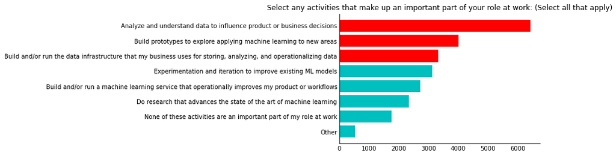

```python
ks.plot_summary("Q23")
```

## 資料分析師使用、推薦的程式語言

主要使用 Python、SQL 與 R，並大力推薦初學者由 Python 入門。

```
What programming languages do you use on a regular basis? (Select all that apply)
Too many categories, only showing the top 10.
```

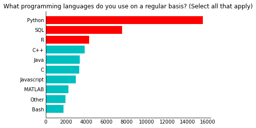

```python
ks.plot_summary("Q7")
```

```
What programming language would you recommend an aspiring data scientist to learn first?
Too many categories, only showing the top 10.
```

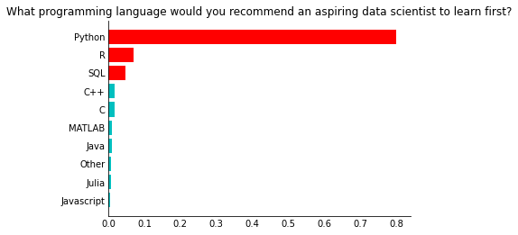

```python
ks.plot_summary("Q8")
```

## 資料分析師的整合開發環境

以 Jupyter、VS Code 與 PyCharm 撰寫 Python、以 RStudio 撰寫 R、以文字編輯器寫作其他語言。

```
Which of the following integrated development environments (IDE's) do you use on a regular basis?  (Select all that apply)
Too many categories, only showing the top 10.
```

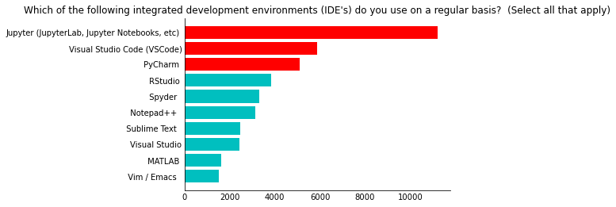

```python
ks.plot_summary("Q9")
```

## 資料分析師的視覺化套件

主要使用的視覺化套件是在 Python 使用 matplotlib、seaborn 與 plotly，在 R 使用 ggplot2 與 plotly。

```
What data visualization libraries or tools do you use on a regular basis?  (Select all that apply)
Too many categories, only showing the top 10.
```

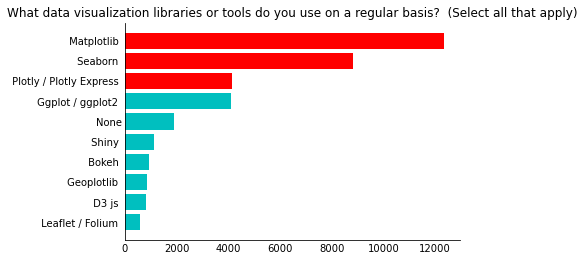

```python
ks.plot_summary("Q14")
```

## 資料分析師的商業智能軟體

主要使用的商業智能軟體是 Tableau 與 PowerBI。

```
Which of the following business intelligence tools do you use on a regular basis? (Select all that apply)
Too many categories, only showing the top 10.
```

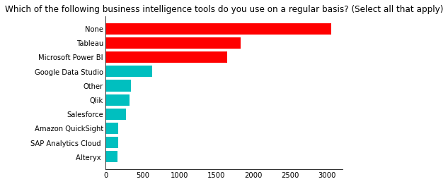

```python
ks.plot_summary('Q31A')
```

## 資料分析師的機器學習框架

主要使用的機器學習框架是 Scikit-Learn 以及深度學習 TensorFlow / Keras。

```
Which of the following machine learning frameworks do you use on a regular basis? (Select all that apply)
Too many categories, only showing the top 10.
```

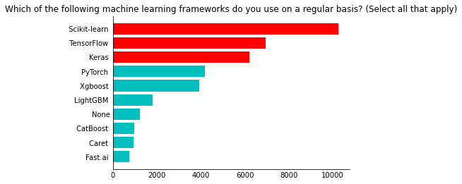

```python
ks.plot_summary('Q16')
```

## 資料分析師的關聯式資料庫管理系統

主要使用的關聯式資料庫為 MySQL、PostgreSQL 與 MS SQL Server。

```
Which of the following big data products (relational databases, data warehouses, data lakes, or similar) do you use on a regular basis? (Select all that apply)
Too many categories, only showing the top 10.
```

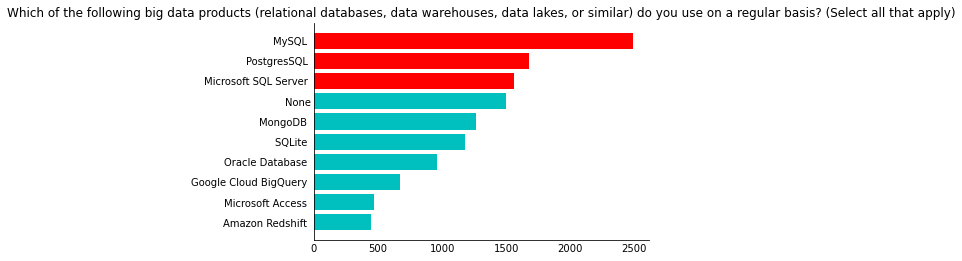

```python
ks.plot_summary('Q29A')
```

## 蒐集資料分析師的[職缺需求](https://docs.google.com/spreadsheets/d/1FycXKy3m4Cz1bSEvvYipCAoKuGSjzLoyJTT7dD7t2Fk/edit?usp=sharing)

- Indeed
- CakeResume
- 104 人力銀行

## 在瀏覽器啟動分析環境

- kaggle-ml-ds-survey-2020.ipynb
- indeed-cakeresume-104.ipynb

## 驗證

## 資料科學團隊面試官訪談

- 資料分析師/資料科學/約會交友 APP
- 資深講師/教育訓練/外商軟體公司
- 副理/信用模型/銀行
- 資料工程師/資料科學/外送 APP

## 資料科學團隊面試官訪談（續）

- 經理/資料科學/電信公司
- 經理/資料科學/保險公司
- 副理/整合行銷/銀行
- 副理/商業智能/電商

## 訪談 8 位面試官三個問題

- 您希望初階資料分析師分別在程式語言、統計、機器學習、視覺化與資料庫五個面向所具備的程度為何？若以 1 非常陌生、5 為非常熟稔，您的期待是？
- 在進行初階資料分析師的面試時，請和我們分享您通常會問的三個「技術問題」。
- 在進行初階資料分析師的面試時，請和我們分享您通常會問的三個「非技術問題」。

## 「如何成為」的部分

## 目標、現況與學習地圖

- 目標描述
- 現況評估
- 學習地圖

## 第零站：跟電腦變成好朋友

寫程式是理解統計知識與機器學習理論不可或缺的工具與手段，因此學習的起點必須從程式設計起步，而在開始寫程式之前我們應該跟電腦變成好朋友！學習操作終端機、文字編輯器還有 Git/GitHub。

懂得如何使用 SQL 之後，可以跟試算表、視覺化軟體搭配開始進行探索性分析，從課程中所分析的 Kaggle 問卷調查我們得知 Tableau 與 PowerBI 是現在最普遍的視覺化軟體，而這兩個都有免費的版本可供個人電腦使用，如果是使用 Windows 作業系統的學員可以都試用，使用 macOS 的學員就使用 Tableau。

## 第三站：學習 Python 程式設計

想要勝任工程導向的資料科學團隊職缺，必須學會一個在專案的各個應用都能介接、並且能夠自己整併清理資料的程式語言，在 2021 年首選是 Python 程式語言。

## 第四站：機器學習應用

先使用第三方套件實作 Kaggle 專案，至於為何所引用的函式與類別能夠完成機器學習應用，則留待後續在研讀理論後融會貫通。

從課程中面試官訪談的部分我們得知，在技術面試時除了會測驗實作，也會詢問第三方套件中相關函式、類別的參數設定以及其背後的理論對應。